# hw10

Peiyuan Zhu

2018-12-01

```r
library(ggplot2)
library(tidyverse)
library(stringr)
library(rvest)
library(httr)
library(jsonlite)
setwd("~/Desktop/stat-545/hw10-garyzhubc")
```

# Scrape data

Use the rvest package to scrape data from the web to make two data objects.

For the first data object, we scrape the aviation incident data from wikipedia by first selecting the node of the desired table. The html is pre-downloaded to avoid connection issues. The data is cleaned using `stringr` package. We make a plot of death per incident over years to indicate severity. As shown, there seems to be a periodic pattern of severity.

```r
# download.file("https://en.wikipedia.org/wiki/Aviation_accidents_and_incidents", destfile = "html/Aviation_accidents_and_incidents.html", quiet=TRUE)

air.incidents <- read_html("html/Aviation_accidents_and_incidents.html") %>%
  html_nodes(xpath='//*[@id="mw-content-text"]/div/table[2]') %>%
  html_table(fill=TRUE) %>%
  .[[1]] %>%
  rename("Deaths"="Deaths[52]") %>%
  rename("Incidents"="# of incidents[53]") %>%
  rowwise() %>%
  mutate(Deaths=as.numeric(str_replace_all(Deaths, "[^0-9.-]", ""))) %>%
  rowwise() %>%
  mutate(Incidents=as.numeric(str_replace_all(Incidents, "\\[.+?\\]", "")))

write_csv(air.incidents,"data/air_incidents.csv")
air.incidents <- read_csv("data/air_incidents.csv")
```

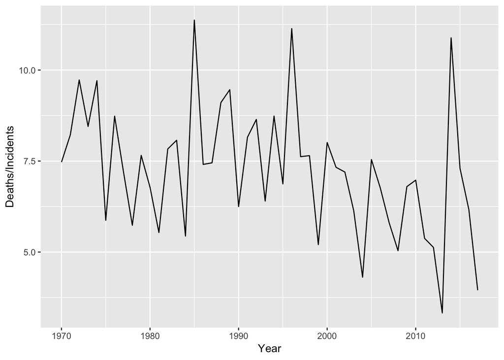

```r
ggplot(air.incidents, aes(x=Year, y=Deaths/Incidents)) +
  geom_line()
```

For the second data object, we scraped the wikipedia page of work by Verdi and made a jitterplot of year of first performance in two different languages. Again the data is cleaned by `stringr`.

```r
# download.file("https://en.wikipedia.org/wiki/List_of_compositions_by_Giuseppe_Verdi", destfile = "html/List_of_compositions_by_Giuseppe_Verdi.html", quiet=TRUE)

opera <- read_html("html/List_of_compositions_by_Giuseppe_Verdi.html") %>%
  html_table(fill=TRUE) %>%
  .[[1]] %>%
  mutate("Year"=as.numeric(str_extract(.$`First performance`, "\\d{4}"))) %>%
  mutate("Language"=str_extract(.$`# Acts, Language`, "(Italian|French)"))

write_csv(opera,"data/opera.csv")
opera <- read_csv("data/opera.csv")
```

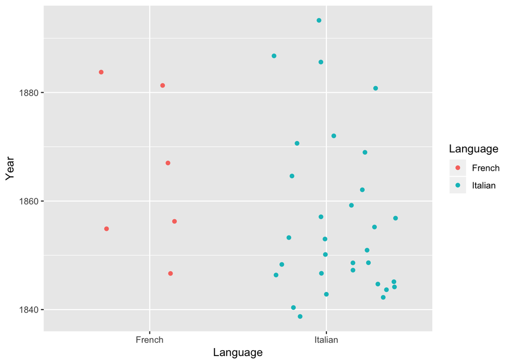

```r
ggplot(opera, aes(x=Language,y=Year,color=Language)) +
  geom_jitter()
```

# Make API queries

For the first data object, we obtain data from fit a linear relationship between starship lengths and maximum atmosphering speed of starships legended by cost. The data is requested from https://swapi.co. Note there is a cap of 1000 requests per day per IP address for this API.

```r
starships1 <- content(GET("https://swapi.co/api/starships/?page=1"))$results
starships2 <- content(GET("https://swapi.co/api/starships/?page=2"))$results
starships3 <- content(GET("https://swapi.co/api/starships/?page=3"))$results
starships4 <- content(GET("https://swapi.co/api/starships/?page=4"))$results
starships <- data.frame(do.call(rbind,list(do.call(rbind,starships1),do.call(rbind,starships2),do.call(rbind,starships3),do.call(rbind,starships4))))

starships$length <- as.integer(starships$length)
starships$max_atmosphering_speed <- as.integer(starships$max_atmosphering_speed)
starships$cost_in_credits <- as.integer(starships$cost_in_credits)
write_csv(select(starships,length,max_atmosphering_speed,cost_in_credits),"data/starships.csv")
starships <- read_csv("data/starships.csv")
```

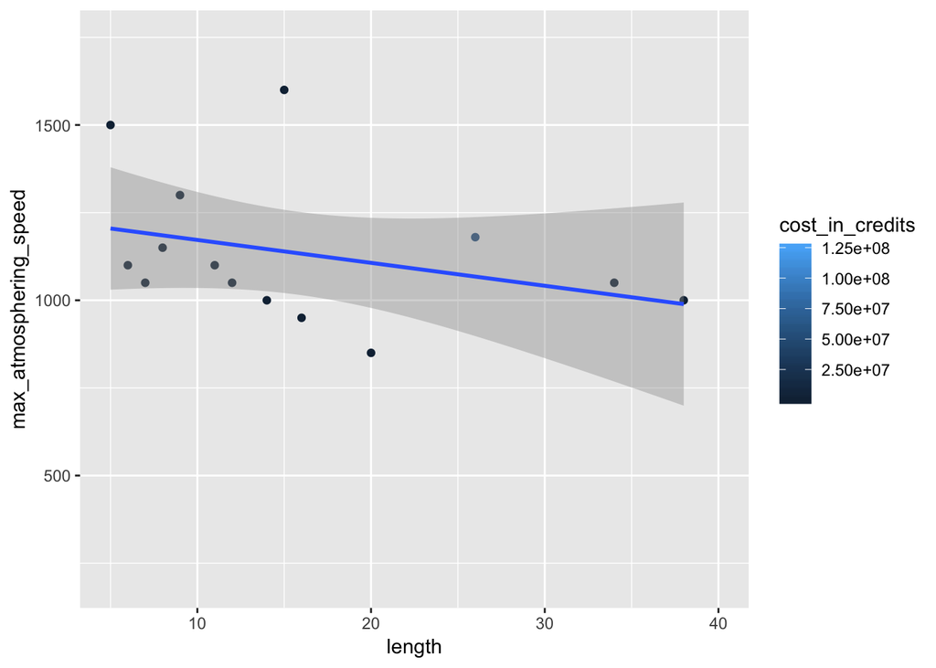

```r
starships %>%
  drop_na() %>%
  ggplot(aes(x=length,y=max_atmosphering_speed,color=cost_in_credits)) +
  geom_point() +
  xlim(5,40) +
  ylim(200,1750) +
  geom_smooth(method="lm")
```

For the second data object, we make a histogram of height distribution of Star Wars people colored by gender.

```r
people1 <- content(GET("https://swapi.co/api/people/?page=1"))$results
people2 <- content(GET("https://swapi.co/api/people/?page=2"))$results
people3 <- content(GET("https://swapi.co/api/people/?page=3"))$results
people4 <- content(GET("https://swapi.co/api/people/?page=4"))$results
people5 <- content(GET("https://swapi.co/api/people/?page=5"))$results
people6 <- content(GET("https://swapi.co/api/people/?page=6"))$results
people7 <- content(GET("https://swapi.co/api/people/?page=7"))$results
people8 <- content(GET("https://swapi.co/api/people/?page=8"))$results
people9 <- content(GET("https://swapi.co/api/people/?page=9"))$results

people <- data.frame(do.call(rbind,list(do.call(rbind,people1),do.call(rbind,people2),do.call(rbind,people3),do.call(rbind,people4),do.call(rbind,people5),do.call(rbind,people6),do.call(rbind,people7),do.call(rbind,people8),do.call(rbind,people9))))

people$height <- as.integer(unlist(people$height))
people$gender <- as.factor(unlist(people$gender))

write_csv(select(people,height,gender),"data/people.csv")
people <- read_csv("data/people.csv",na=c("n/a","NA"))
```

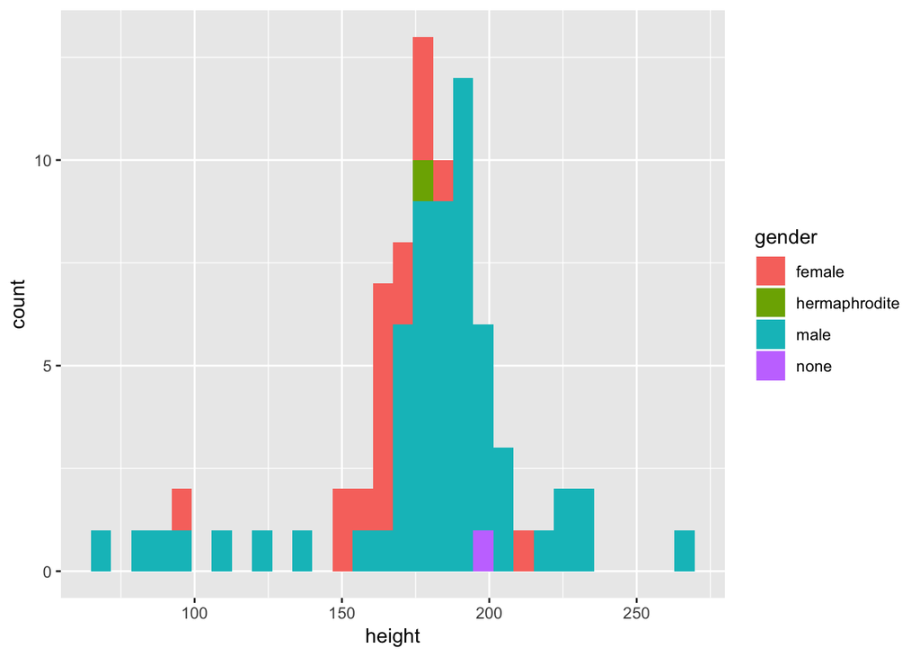

```r
people %>%
  drop_na() %>%
  ggplot(aes(x=height,fill=gender)) +
  geom_histogram()
```